# $d_L(z)$ Simulation for Einstein Telescope with Fake SFR Distribution

First of all let us load all necessaries libraries to run our code. Here we are going to use the Flat $\Lambda CDM$ model as fiducial model with cosmological parameters $H_0 = 73\ km/s/Mpc$ and $\Omega_m = 0.3$.

```python
import numpy as np
import matplotlib.pyplot as plt
from scipy.integrate import quad, odeint
from pynverse import inversefunc
from astropy.cosmology import FlatLambdaCDM
from tqdm import tqdm

cosmo = FlatLambdaCDM(H0=73,Om0=0.3)
km_Mpc = 1.e3/3.086e22
```

The next step is define the estimated uncertainty of $d_L$ (toy model) using the Einstein Telescope. This toy model consistis in supose that the uncertainty $\Delta d_L(z)$ behaves inverselly proportional to the Signal to Noise ratio (SNR):

\begin{equation} \frac{\Delta d_L}{d_L} \approx \frac{2}{SNR} \qquad where \qquad SNR = 2\left[\int_0^{\infty} \frac{df}{S_n(f)}|\tilde{h}(f)|^2 \right]^{1/2} \end{equation}

Also we are going to define a function that returns the comoving volume per unity of redshift as:

\begin{equation} \frac{dV_c}{dz} = \frac{4\pi d_L^2(z)}{(1+z)^2H(z)} \end{equation}

```python
# Computing dL uncertainty:
def Err(z,dL): return ( 0.1618*z - 0.0289*z**2 + 0.002*z**3 )*dL

# Computing Comoving Volume per Redshift:
def dVc_dz(z):
	dL = cosmo.luminosity_distance(z).value
	H = cosmo.H(z).value*km_Mpc
	return 4*np.pi*dL**2/((1.+z)**2*H)
```

In the following code block we are going to start modeling our fake events distribution modifying the equation of star formation rate given in (arXiv:1403.0007):

\begin{equation} \psi(z) \equiv \frac{dN}{dtdV_c} = \phi_0\frac{(1+z)^{\alpha}}{1+\left[\frac{1+z}{C}\right]^{\beta}} \end{equation}

Our modification will be modifying the coefficient C in order to pull the peack of the distribution to be approximatelly in $z=1$.

```python
z_star = 1 # Redshift of the Maximum Distribution
phi0, alpha, beta = 0.015, 2.7, 5.6
C = (z_star+1)*pow(beta/alpha-1, 1/beta) # C = 2.9 in (arXiv:1403.0007)
def SFR(z): return phi0*(1+z)**alpha/(1+((1+z)/C)**beta) # Star Formation Rate
def Auxiliar(z): return dVc_dz(z)*SFR(z)/(1+z)
```

The function called Auxiliar(z) will define our source distribution that will be normalized aftermore.

\begin{equation} \frac{dN}{dt_{obs}dz} = \frac{\psi(z)}{n(1+z)}\frac{dV_c}{dz} \end{equation}

where n is choosen such that:

\begin{equation} \int_0^{z_{max}} \frac{dN}{dt_{obs}dz} dz = N_{tot} \end{equation}

Here we would like to deal with a total number of sources $N_{tot}=100$ distributed in the redshift range between 0 and 2

```python
# Computing the Normalization Constant
Ntot = 100 ; z_max = 2	# Total number of sources and maximum redshift
n, _ = quad(Auxiliar, 0, z_max)
n /= Ntot
```

Computed the normalization constant $n$ we can define the resulting cumulative distribution function $\mathcal{N}(z)$:

\begin{equation} \mathcal{N}(z) \equiv \int_0^{\infty}\frac{dN}{dt_{obs}dz}dz \end{equation}

```python
# Defining Our Data Distribution Function
def Pz(z): return Auxiliar(z)/n

def Nz(z): # N(z)
	x,_ = quad(Pz, 0, z)
	return x
```

With the function $\mathcal{N}(z)$ in hand we would like to invert this function to be $z(\mathcal{N})$ in order to set the redshifts were our sources will be placed. For example, the first source will be placed at $z(\mathcal{N}=1)$, the second one in $z(\mathcal{N}=2)$ and so on until the last source be placed at $z(\mathcal{N}=N_{tot})$.

With the redshift source positions and the values of $\Delta d_L(z)$, we are going to compute the luminosity distance $d_L(z)$ using our fiducial model and scattering these values from a Gaussian distribution:

\begin{equation} \mathbf{data}(d_L) \sim N(\mu = d_L, \sigma = \Delta dL) \end{equation}

```python
N = np.linspace(1,Ntot,Ntot)
z = np.zeros(Ntot)
for i in tqdm(range(Ntot)): z[i] = inversefunc(Nz , N[i], domain=[1.e-10,3])

dL = cosmo.luminosity_distance(z).value
Error = Err(z,dL)
data = np.random.normal( dL, Error )
```

Finaly we can plot our results.

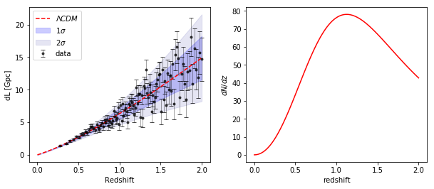

```python
data/=1.e3 ; Error/=1.e3 ; dL/=1.e3
fig = plt.figure(figsize=(10,4))
plt.subplot(1,2,1)
plt.errorbar( z, data, Error, fmt='k.', capsize=3, elinewidth=0.5, alpha=0.7,label='data')
z = np.linspace(0,2,100); dL = cosmo.luminosity_distance(z).value/1.e3; Error = Err(z,dL)
plt.fill_between(z,dL+Error,dL-Error,color='blue',alpha=0.2,label='$1\sigma$')
plt.fill_between(z,dL+2*Error,dL-2*Error,color='darkblue',alpha=0.1,label='$2\sigma$')
plt.plot(z,dL,'r--',label='$\Lambda CDM$'); plt.legend(loc='best')
plt.xlabel('Redshift'); plt.ylabel('dL [Gpc]')

plt.subplot(1,2,2)
plt.plot(z,Pz(z),'r-')
plt.xlabel('redshift'); plt.ylabel('$dN/dz$')
fig.savefig('simple_p.png')
plt.show()
```